# Tugas Mingu 3

Rakesha Putra Antique Yusuf

2024-09-02

# Pemanggilan Package

```r
library(dplyr)
library(TTR)
library(forecast)
library(lmtest)
library(orcutt)
library(HoRM)
```

```r
library(ggplot2)
```

# Input Data

```r
data <- readxl::read_xlsx("C:/Users/RAKESHA/Downloads/Data GDP LIberia.xlsx")
data
```

```
## # A tibble: 64 × 2
##    Tahun        GDP
##    <dbl>      <dbl>
##  1  1960 190495600.
##  2  1961 183920900.
##  3  1962 191861800.
##  4  1963 200229600.
##  5  1964 218929100.
##  6  1965 229260800.
##  7  1966 244459500.
##  8  1967 261024300.
##  9  1968 276820700.
## 10  1969 306961800.
## # ℹ 54 more rows
```

```r
data <- as.data.frame(data)
```

```r
data.ts<-ts(data$GDP)
data.ts
```

```
## Time Series:
## Start = 1
## End = 64
## Frequency = 1
##  [1]  190495600  183920900  191861800  200229600  218929100  229260800
##  [7]  244459500  261024300  276820700  306961800  323099700  341543100
## [13]  368098000  386968300  486955000  577549300  596675700  673010600
## [19]  717240400  814067900  854711500  846514500  863933200  823374900
## [25]  848478300  851296100  840964400  972800000 1038300000  786300000
## [31]  384400000  348000000  223500000  160400000  132200000  134800000
## [37]  159400000  295900000  359600000  441800000  874000000  906000000
## [43]  927000000  748000000  897000000  949000000 1119000000 1373000000
## [49] 1726000000 1768000000 1998000000 2398000000 2791614000 3177198100
## [55] 3225652000 3227075700 3398419600 3390703400 3422754800 3319596500
## [61] 3176126340 3513049520 4001047000 4332000000
```

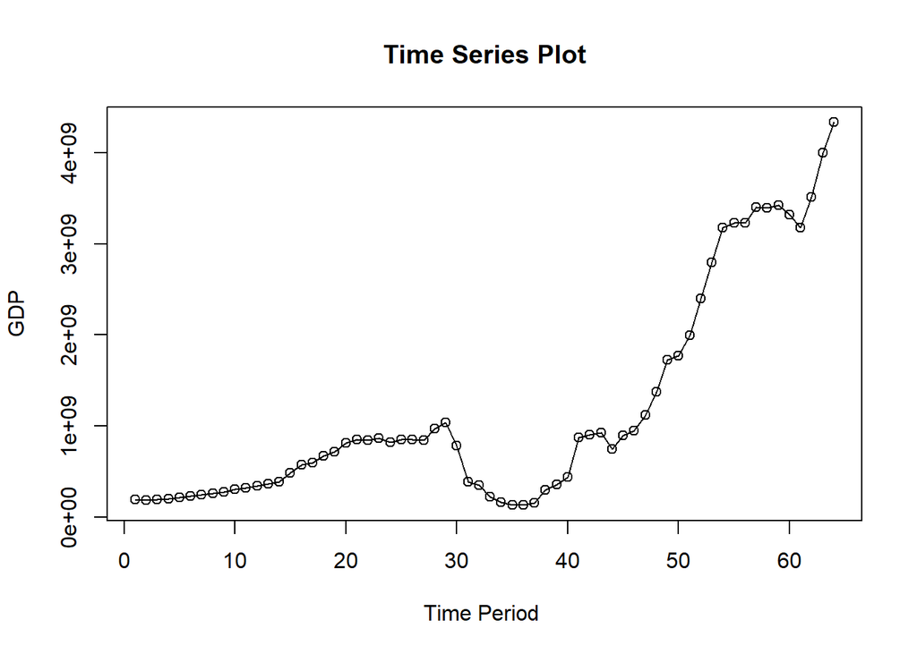

```r
ts.plot(data.ts, xlab="Time Period ", ylab="GDP",
        main = "Time Series Plot")
points(data.ts)
```

```r
data2 <- data[44:64,]
data2
```

```
##    Tahun        GDP
## 44  2003  748000000
## 45  2004  897000000
## 46  2005  949000000
## 47  2006 1119000000
## 48  2007 1373000000
## 49  2008 1726000000
## 50  2009 1768000000
## 51  2010 1998000000
## 52  2011 2398000000
## 53  2012 2791614000
## 54  2013 3177198100
## 55  2014 3225652000
## 56  2015 3227075700
## 57  2016 3398419600
## 58  2017 3390703400
## 59  2018 3422754800
## 60  2019 3319596500
## 61  2020 3176126340
## 62  2021 3513049520
## 63  2022 4001047000
## 64  2023 4332000000
```

```r
data2.ts <- ts(data2$GDP)
```

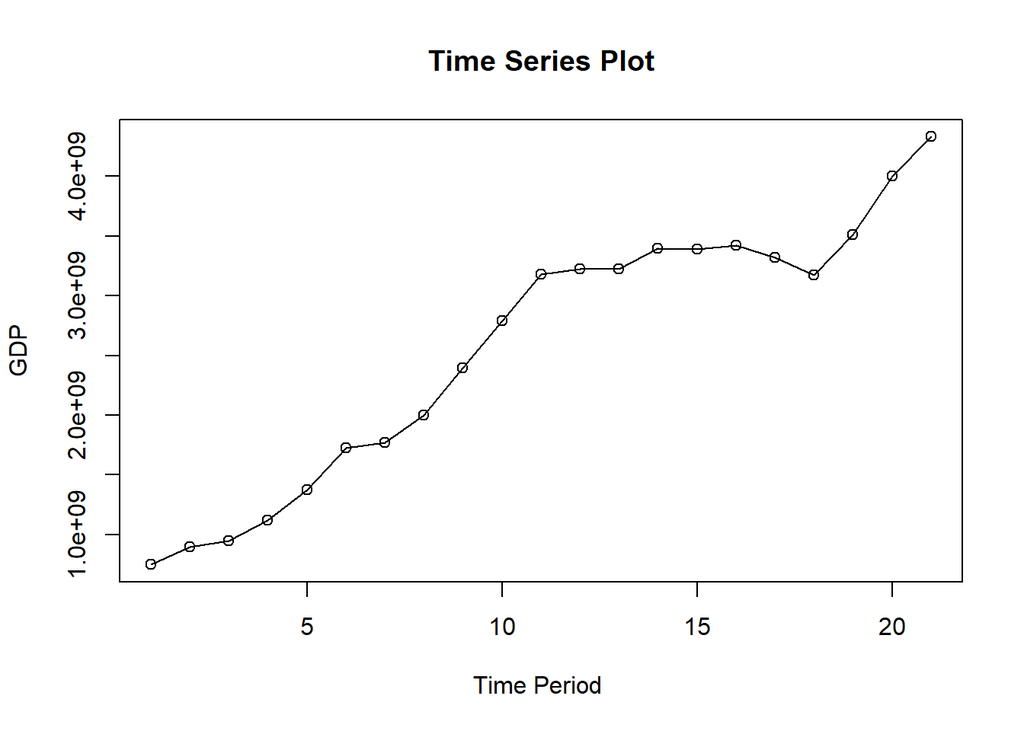

```r
ts.plot(data2.ts, xlab="Time Period ", ylab="GDP",
        main = "Time Series Plot")
points(data2.ts)
```

# Eksplorasi Data

```r
training_ma <- data2[1:18,]
testing_ma <- data2[19:21,]
train_ma.ts <- ts(training_ma$GDP)
test_ma.ts <- ts(testing_ma$GDP)
```

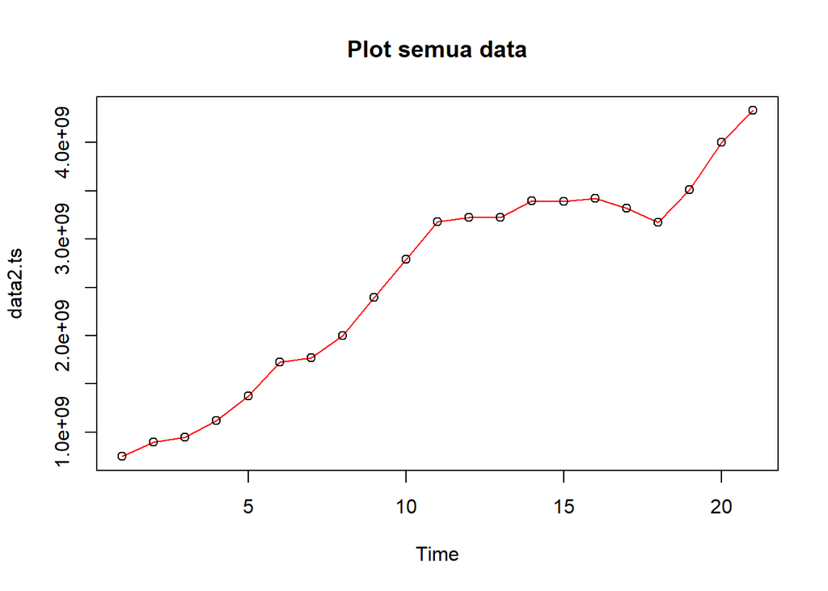

```r
#eksplorasi keseluruhan data
plot(data2.ts, col="red",main="Plot semua data")
points(data2.ts)
```

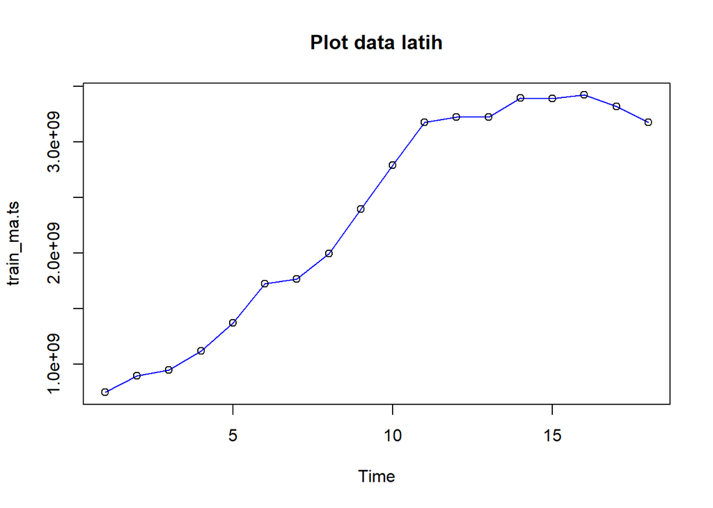

```r
#eksplorasi data latih
plot(train_ma.ts, col="blue",main="Plot data latih")
points(train_ma.ts)
```

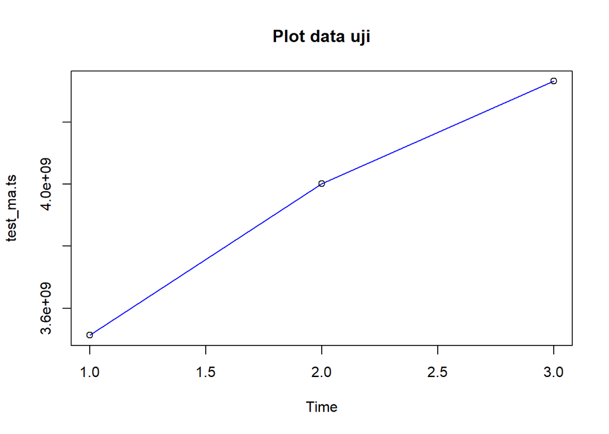

```r
#eksplorasi data uji
plot(test_ma.ts, col="blue",main="Plot data uji")
points(test_ma.ts)
```

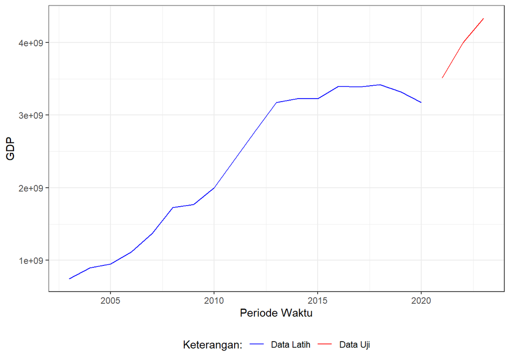

```r
ggplot() +
  geom_line(data = training_ma, aes(x = Tahun, y = GDP, col = "Data Latih")) +
  geom_line(data = testing_ma, aes(x = Tahun, y = GDP, col = "Data Uji")) +
  labs(x = "Periode Waktu", y = "GDP", color = "Legend") +
  scale_colour_manual(name="Keterangan:", breaks = c("Data Latih", "Data Uji"),
                      values = c("blue", "red")) +
  theme_bw() + theme(legend.position = "bottom",
                     plot.caption = element_text(hjust=0.5, size=12))
```

# Pemulusan Single Moving Average

```r
data.sma<-SMA(train_ma.ts, n=1)
data.sma
```

```
## Time Series:
## Start = 1
## End = 18
## Frequency = 1
##  [1]  748000000  897000000  949000000 1119000000 1373000000 1726000000
##  [7] 1768000000 1998000000 2398000000 2791614000 3177198100 3225652000
## [13] 3227075700 3398419600 3390703400 3422754800 3319596500 3176126340
```

```r
data.ramal<-c(NA,data.sma)
data.ramal
```

```
##  [1]         NA  748000000  897000000  949000000 1119000000 1373000000
##  [7] 1726000000 1768000000 1998000000 2398000000 2791614000 3177198100
## [13] 3225652000 3227075700 3398419600 3390703400 3422754800 3319596500
## [19] 3176126340
```

```r
length_max <- max(length(train_ma.ts), length(data.sma), length(data.ramal) + 4)

aktual <- c(train_ma.ts, rep(NA, length_max - length(train_ma.ts)))
pemulusan <- c(data.sma, rep(NA, length_max - length(data.sma)))
ramalan <- c(data.ramal, rep(data.ramal[length(data.ramal)], 4))

data.gab <- cbind(aktual = aktual, pemulusan = pemulusan, ramalan = ramalan)
data.gab
```

```
##           aktual  pemulusan    ramalan
##  [1,]  748000000  748000000         NA
##  [2,]  897000000  897000000  748000000
##  [3,]  949000000  949000000  897000000
##  [4,] 1119000000 1119000000  949000000
##  [5,] 1373000000 1373000000 1119000000
##  [6,] 1726000000 1726000000 1373000000
##  [7,] 1768000000 1768000000 1726000000
##  [8,] 1998000000 1998000000 1768000000
##  [9,] 2398000000 2398000000 1998000000
## [10,] 2791614000 2791614000 2398000000
## [11,] 3177198100 3177198100 2791614000
## [12,] 3225652000 3225652000 3177198100
## [13,] 3227075700 3227075700 3225652000
## [14,] 3398419600 3398419600 3227075700
## [15,] 3390703400 3390703400 3398419600
## [16,] 3422754800 3422754800 3390703400
## [17,] 3319596500 3319596500 3422754800
## [18,] 3176126340 3176126340 3319596500
## [19,]         NA         NA 3176126340
## [20,]         NA         NA 3176126340
## [21,]         NA         NA 3176126340
## [22,]         NA         NA 3176126340
## [23,]         NA         NA 3176126340
```

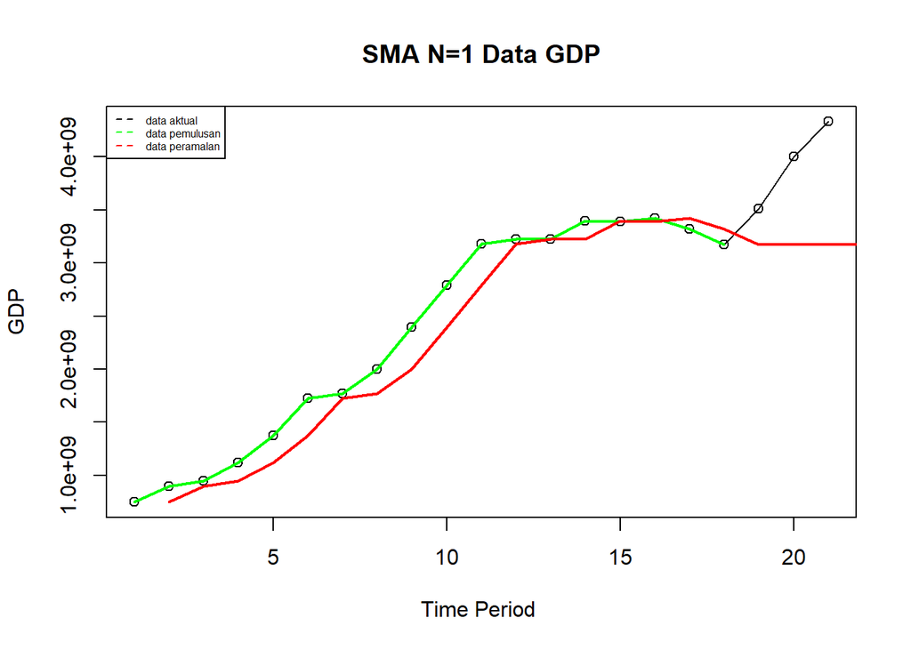

```r
ts.plot(data2.ts, xlab="Time Period ", ylab="GDP", main= "SMA N=1 Data GDP")
points(data2.ts)
lines(data.gab[,2],col="green",lwd=2)
lines(data.gab[,3],col="red",lwd=2)
legend("topleft",c("data aktual","data pemulusan","data peramalan"), lty=8, col=c("black","green","red"), cex=0.5)
```

## Tingkat Akurasi dari Hasil Pemulusan SMA Data Latih

```r
error_train.sma = train_ma.ts-data.ramal[1:length(train_ma.ts)]
SSE_train.sma = sum(error_train.sma[5:length(train_ma.ts)]^2)
MSE_train.sma = mean(error_train.sma[5:length(train_ma.ts)]^2)
MAPE_train.sma = mean(abs((error_train.sma[5:length(train_ma.ts)]/train_ma.ts[5:length(train_ma.ts)])*100))

akurasi_train.sma <- matrix(c(SSE_train.sma, MSE_train.sma, MAPE_train.sma))
row.names(akurasi_train.sma)<- c("SSE", "MSE", "MAPE")
colnames(akurasi_train.sma) <- c("Akurasi m = 1")
akurasi_train.sma
```

```
##      Akurasi m = 1
## SSE   7.714168e+17
## MSE   5.510120e+16
## MAPE  7.937990e+00
```

MAPE pada data latih adalah 7,9, ini berarti bahwa rata-rata kesalahan prediksi model pada data latih adalah 7,9% dari nilai aktual.

## Tingkat Akurasi dari Hasil Pemulusan SMA Data Uji

```r
error_test.sma = test_ma.ts-data.gab[18:20,3]
SSE_test.sma = sum(error_test.sma^2)
MSE_test.sma = mean(error_test.sma^2)
MAPE_test.sma = mean(abs((error_test.sma/test_ma.ts*100)))

akurasi_test.sma <- matrix(c(SSE_test.sma, MSE_test.sma, MAPE_test.sma))
row.names(akurasi_test.sma)<- c("SSE", "MSE", "MAPE")
colnames(akurasi_test.sma) <- c("Akurasi m = 1")
akurasi_test.sma
```

```
##      Akurasi m = 1
## SSE   2.053962e+18
## MSE   6.846540e+17
## MAPE  1.760218e+01
```

Nilai MAPE (Mean Absolute Percentage Error) sebesar 1.760218e+01 pada data uji mengindikasikan bahwa rata-rata kesalahan prediksi model pada data uji adalah sekitar 17.6% dari nilai aktual.

# Pemulusan Double Moving Average

```r
dma <- SMA(data.sma, n = 1)
At <- 2*data.sma - dma
Bt <- 2/(4-1)*(data.sma - dma)
data.dma<- At+Bt
data.ramal2<- c(NA, data.dma)

t = 1:4
f = c()

for (i in t) {
  f[i] = At[length(At)] + Bt[length(Bt)]*(i)
}

data.gab2 <- cbind(aktual = c(train_ma.ts,rep(NA,4)), pemulusan1 = c(data.sma,rep(NA,4)),pemulusan2 = c(data.dma, rep(NA,4)),At = c(At, rep(NA,4)), Bt = c(Bt,rep(NA,4)),ramalan = c(data.ramal2, f[-1]))
data.gab2
```

```
##           aktual pemulusan1 pemulusan2         At Bt    ramalan
##  [1,]  748000000  748000000  748000000  748000000  0         NA
##  [2,]  897000000  897000000  897000000  897000000  0  748000000
##  [3,]  949000000  949000000  949000000  949000000  0  897000000
##  [4,] 1119000000 1119000000 1119000000 1119000000  0  949000000
##  [5,] 1373000000 1373000000 1373000000 1373000000  0 1119000000
##  [6,] 1726000000 1726000000 1726000000 1726000000  0 1373000000
##  [7,] 1768000000 1768000000 1768000000 1768000000  0 1726000000
##  [8,] 1998000000 1998000000 1998000000 1998000000  0 1768000000
##  [9,] 2398000000 2398000000 2398000000 2398000000  0 1998000000
## [10,] 2791614000 2791614000 2791614000 2791614000  0 2398000000
## [11,] 3177198100 3177198100 3177198100 3177198100  0 2791614000
## [12,] 3225652000 3225652000 3225652000 3225652000  0 3177198100
## [13,] 3227075700 3227075700 3227075700 3227075700  0 3225652000
## [14,] 3398419600 3398419600 3398419600 3398419600  0 3227075700
## [15,] 3390703400 3390703400 3390703400 3390703400  0 3398419600
## [16,] 3422754800 3422754800 3422754800 3422754800  0 3390703400
## [17,] 3319596500 3319596500 3319596500 3319596500  0 3422754800
## [18,] 3176126340 3176126340 3176126340 3176126340  0 3319596500
## [19,]         NA         NA         NA         NA NA 3176126340
## [20,]         NA         NA         NA         NA NA 3176126340
## [21,]         NA         NA         NA         NA NA 3176126340
## [22,]         NA         NA         NA         NA NA 3176126340
```

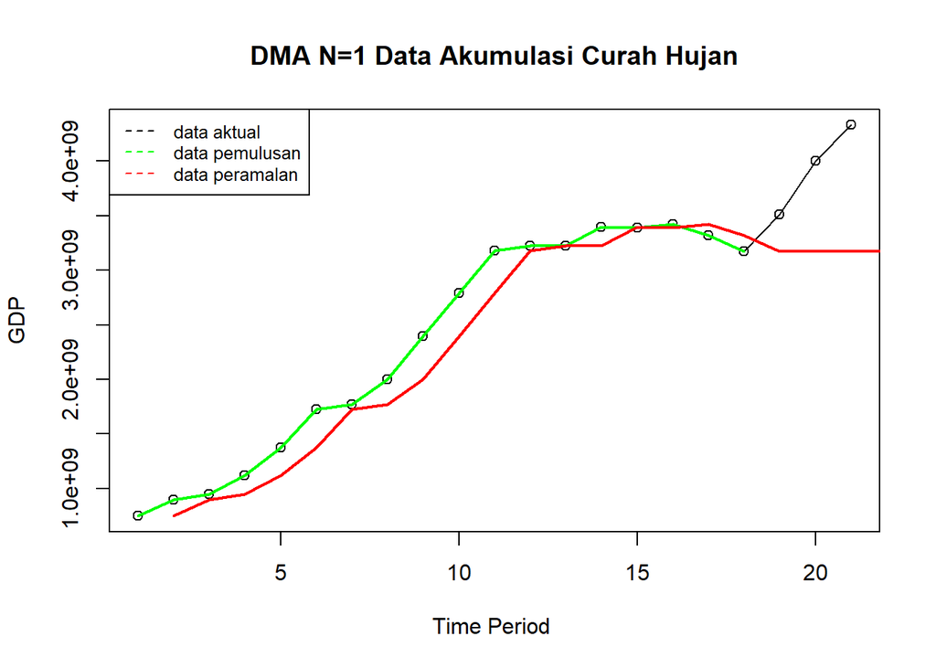

```r
ts.plot(data2.ts, xlab="Time Period ", ylab="GDP", main= "DMA N=1 Data Akumulasi Curah Hujan")
points(data2.ts)
lines(data.gab2[,3],col="green",lwd=2)
lines(data.gab2[,6],col="red",lwd=2)
legend("topleft",c("data aktual","data pemulusan","data peramalan"), lty=8, col=c("black","green","red"), cex=0.8)
```

## Tingkat Akurasi dari Hasil Pemulusan DMA Data Latih

```r
error_train.dma = train_ma.ts-data.ramal2[1:length(train_ma.ts)]
SSE_train.dma = sum(error_train.dma[8:length(train_ma.ts)]^2)
MSE_train.dma = mean(error_train.dma[8:length(train_ma.ts)]^2)
MAPE_train.dma = mean(abs((error_train.dma[8:length(train_ma.ts)]/train_ma.ts[8:length(train_ma.ts)])*100))

akurasi_train.dma <- matrix(c(SSE_train.dma, MSE_train.dma, MAPE_train.dma))
row.names(akurasi_train.dma)<- c("SSE", "MSE", "MAPE")
colnames(akurasi_train.dma) <- c("Akurasi m = 1")
akurasi_train.dma
```

```
##      Akurasi m = 1
## SSE   5.805278e+17
## MSE   5.277525e+16
## MAPE  6.345886e+00
```

MAPE pada data latih adalah 6.345886e+00, ini berarti bahwa rata-rata kesalahan prediksi model pada data latih adalah 6.346% dari nilai aktual.

## Tingkat Akurasi dari Hasil Pemulusan DMA Data Uji

```r
error_test.dma = test_ma.ts-data.gab[18:20,2]
SSE_test.dma = sum(error_test.dma^2)
MSE_test.dma = mean(error_test.dma^2)
MAPE_test.dma = mean(abs((error_test.dma/test_ma.ts*100)))

akurasi_test.dma <- matrix(c(SSE_test.dma, MSE_test.dma, MAPE_test.dma))
row.names(akurasi_test.dma)<- c("SSE", "MSE", "MAPE")
colnames(akurasi_test.dma) <- c("Akurasi m = 1")
akurasi_test.dma
```

```
##      Akurasi m = 1
## SSE             NA
## MSE             NA
## MAPE            NA
```

# Regresi

```r
model<- lm(GDP~Tahun, data = data2)
summary(model)
```

```
##
## Call:
## lm(formula = GDP ~ Tahun, data = data2)
##
## Residuals:
##        Min         1Q     Median         3Q        Max
## -589673985 -170368976  -58237749  170805993  608091578
##
## Coefficients:
##               Estimate Std. Error t value Pr(>|t|)
## (Intercept) -3.416e+11  2.252e+10  -15.17 4.51e-12 ***
## Tahun        1.710e+08  1.119e+07   15.28 3.95e-12 ***
## ---
## Signif. codes:  0 '***' 0.001 '**' 0.01 '*' 0.05 '.' 0.1 ' ' 1
##
## Residual standard error: 310400000 on 19 degrees of freedom
## Multiple R-squared:  0.9248, Adjusted R-squared:  0.9208
## F-statistic: 233.6 on 1 and 19 DF,  p-value: 3.954e-12
```

Model yang dihasilkan adalah
$$y_i=(-3.416e+11)+ (1.710e+08)x_t$$
Berdasarkan ringkasan model dapat diketahui bahwa hasil uji F memiliki *p-value* < $\alpha$ (5%). Artinya, minimal terdapat satu variabel yang berpengaruh nyata terhadap model. Hasil uji-t parsial kedua parameter regresi, yaitu intersep dan koefisien regresi juga menunjukkan hal yang sama, yaitu memiliki *p-value* < $\alpha$ (5%) sehingga nyata dalam taraf 5%. Selanjutnya dapat dilihat juga nilai $R^2=0.9248$. Artinya, sebesar 92.48% keragaman nilai GDP dapat dijelaskan oleh peubah tahun.

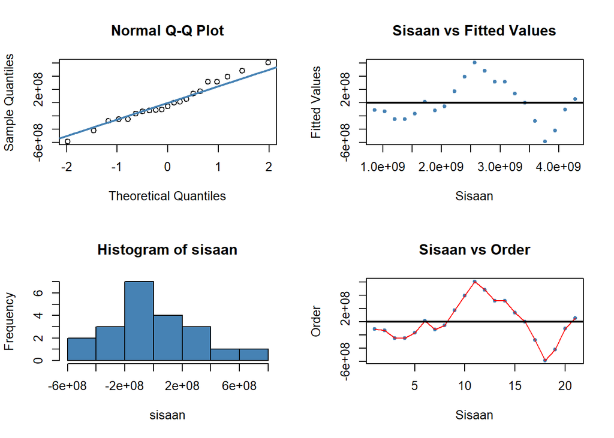

```r
#sisaan dan fitted value
sisaan<- residuals(model)
fitValue<- predict(model)

#Diagnostik dengan eksploratif
par(mfrow = c(2,2))
qqnorm(sisaan)
qqline(sisaan, col = "steelblue", lwd = 2)
plot(fitValue, sisaan, col = "steelblue", pch = 20, xlab = "Sisaan", ylab = "Fitted Values", main = "Sisaan vs Fitted Values")
abline(a = 0, b = 0, lwd = 2)
hist(sisaan, col = "steelblue")
plot(seq(1,21,1), sisaan, col = "steelblue", pch = 20, xlab = "Sisaan", ylab = "Order", main = "Sisaan vs Order")
lines(seq(1,21,1), sisaan, col = "red")
abline(a = 0, b = 0, lwd = 2)
```

## Uji Formal Asumsi Sisaan Mengikuti Sebaran Normal

```r
#H0: sisaan mengikuti sebaran normal
#H1: sisaan tidak mengikuti sebaran normal
shapiro.test(sisaan)
```

```
##
##  Shapiro-Wilk normality test
##
## data:  sisaan
## W = 0.97797, p-value = 0.8937
```

```r
ks.test(sisaan, "pnorm", mean=mean(sisaan), sd=sd(sisaan))
```

```
##
##  Exact one-sample Kolmogorov-Smirnov test
##
## data:  sisaan
## D = 0.11399, p-value = 0.9194
## alternative hypothesis: two-sided
```

Berdasarkan uji formal Saphiro-Wilk dan Kolmogorov-Smirnov didapatkan nilai *p-value* > $\alpha$ (5%). Artinya, cukup bukti untuk menyatakan sisaan berdistribusi normal.

## Identifikasi Autokorelasi

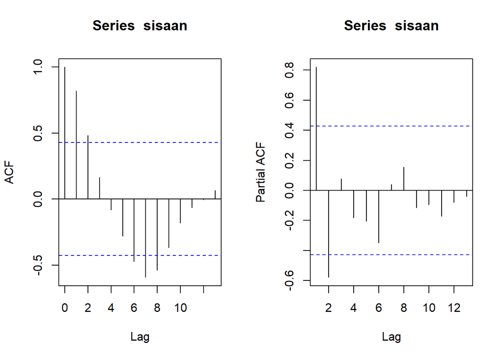

```r
par(mfrow = c(1,2))
acf(sisaan)
pacf(sisaan)
```

## Uji Formal Mendeteksi Autokorelai

```r
#H0: tidak ada autokorelasi
#H1: ada autokorelasi
dwtest(model)
```

```
##
##  Durbin-Watson test
##
## data:  model
## DW = 0.35268, p-value = 3.393e-08
## alternative hypothesis: true autocorrelation is greater than 0
```

Berdasarkan hasil DW Test, didapatkan nilai $DW = 0.35268$ dan *p-value* = $3.393e-08$. Berdasarkan tabel Durbin-Watson diperoleh nilai $DL = 1.21$ dan $DU = 1.54 $. Nilai DW masih berada di bawah nilai DL . Artinya, dapat dikatakan berada di daerah autokorelasi positif. Dan juga, dengan nilai *p-value* < 0.05 dapat disimpulkan bahwa tolak H0, cukup bukti mengatakan adanya autokorelasi. Oleh karena itu, diperlukan penangan autokorelasi. Penanganan yang akan digunakan menggunakan dua metode, yaitu Cochrane-Orcutt dan Hildret-Lu.

# Penanganan Autokorelasi

## Metode Cochrane-Orcutt

```r
modelCO<-cochrane.orcutt(model)
modelCO
```

```
## Cochrane-orcutt estimation for first order autocorrelation
##
## Call:
## lm(formula = GDP ~ Tahun, data = data2)
##
##  number of interaction: 5
##  rho 0.820659
##
## Durbin-Watson statistic
## (original):    0.35268 , p-value: 3.393e-08
## (transformed): 0.99363 , p-value: 2.933e-03
##
##  coefficients:
##   (Intercept)         Tahun
## -329480218382     164989029
```

### Mencari rho optimum

```r
rho<- modelCO$rho
rho
```

```
## [1] 0.8206587
```

## Transformasi Manual

```r
ipm.trans<- data2$GDP[-1]-data2$GDP[-21]*rho
tahun.trans<- data2$Tahun[-1]-data2$Tahun[-21]*rho
modelCOmanual<- lm(ipm.trans~tahun.trans)
summary(modelCOmanual)
```

```
##
## Call:
## lm(formula = ipm.trans ~ tahun.trans)
##
## Residuals:
##        Min         1Q     Median         3Q        Max
## -364599090 -119345030    1098946  139195627  276891541
##
## Coefficients:
##               Estimate Std. Error t value Pr(>|t|)
## (Intercept) -5.909e+10  1.411e+10  -4.189 0.000552 ***
## tahun.trans  1.650e+08  3.898e+07   4.233 0.000500 ***
## ---
## Signif. codes:  0 '***' 0.001 '**' 0.01 '*' 0.05 '.' 0.1 ' ' 1
##
## Residual standard error: 180300000 on 18 degrees of freedom
## Multiple R-squared:  0.4989, Adjusted R-squared:  0.471
## F-statistic: 17.92 on 1 and 18 DF,  p-value: 5e-04
```

```r
b0bintang <- modelCOmanual$coefficients[-2]
b0 <- b0bintang/(1-rho)
b1 <- modelCOmanual$coefficients[-1]
b0
```

```
##   (Intercept)
## -329480218382
```

```r
b1
```

```
## tahun.trans
##   164989029
```

## Metode Hildreth-Lu

### Mencari rho Minimum

```r
hildreth.lu.func<- function(r, model){
  x <- model.matrix(model)[,-1]
  y <- model.response(model.frame(model))
  n <- length(y)
  t <- 2:n
  y <- y[t]-r*y[t-1]
  x <- x[t]-r*x[t-1]

  return(lm(y~x))
}

r <- c(seq(0.1,0.9, by= 0.1))
tab <- data.frame("rho" = r, "SSE" = sapply(r, function(i){deviance(hildreth.lu.func(i, model))}))
round(tab, 4)
```

```
##   rho          SSE
## 1 0.1 1.533618e+18
## 2 0.2 1.288578e+18
## 3 0.3 1.080074e+18
## 4 0.4 9.081084e+17
## 5 0.5 7.726797e+17
## 6 0.6 6.737883e+17
## 7 0.7 6.114342e+17
## 8 0.8 5.856175e+17
## 9 0.9 5.963380e+17
```

```r
rOpt <- seq(0.7,0.9, by= 0.001)
tabOpt <- data.frame("rho" = rOpt, "SSE" = sapply(rOpt, function(i){deviance(hildreth.lu.func(i, model))}))
head(tabOpt[order(tabOpt$SSE),])
```

```
##       rho          SSE
## 122 0.821 5.848380e+17
## 121 0.820 5.848386e+17
## 123 0.822 5.848411e+17
## 120 0.819 5.848428e+17
## 124 0.823 5.848478e+17
## 119 0.818 5.848507e+17
```

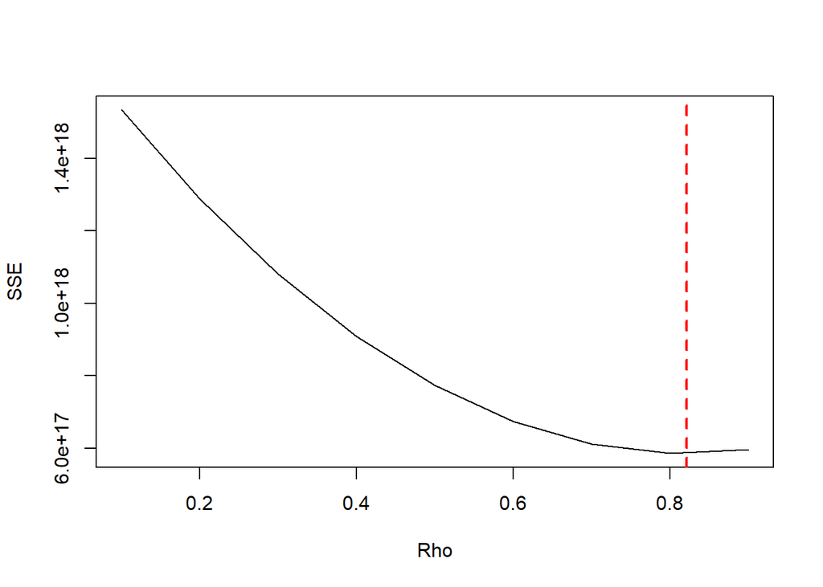

```r
par(mfrow = c(1,1))
plot(tab$SSE ~ tab$rho , type = "l", xlab = "Rho", ylab = "SSE")
abline(v = tabOpt[tabOpt$SSE==min(tabOpt$SSE),"rho"], lty = 2, col="red",lwd=2)
text(x=0.341, y=0.2397500, labels = "rho=0.341", cex = 0.8)
```

Perhitungan yang dilakukan aplikasi `R` menunjukkan bahwa nilai $ρ$ optimum, yaitu saat SSE terkecil terdapat pada nilai $ρ=0.821$. Hal tersebut juga ditunjukkan pada plot.

```r
#Model terbaik
modelHL <- hildreth.lu.func(0.821, model)
summary(modelHL)
```

```
##
## Call:
## lm(formula = y ~ x)
##
## Residuals:
##        Min         1Q     Median         3Q        Max
## -364507922 -119409431    1038370  139247934  276756479
##
## Coefficients:
##               Estimate Std. Error t value Pr(>|t|)
## (Intercept) -5.897e+10  1.411e+10  -4.181 0.000562 ***
## x            1.650e+08  3.905e+07   4.225 0.000509 ***
## ---
## Signif. codes:  0 '***' 0.001 '**' 0.01 '*' 0.05 '.' 0.1 ' ' 1
##
## Residual standard error: 180300000 on 18 degrees of freedom
## Multiple R-squared:  0.4979, Adjusted R-squared:   0.47
## F-statistic: 17.85 on 1 and 18 DF,  p-value: 0.0005093
```

```r
#Transformasi Balik
cat("y = ", coef(modelHL)[1]/(1-0.821), "+", coef(modelHL)[2],"x", sep = "")
```

```
## y = -329460345233+164979256x
```

Setelah dilakukan tranformasi balik, didapatkan model dengan metode Hildreth-Lu sebagai berikut.
$$y_i=
-329460345233+164979256x_t$$

```r
#H0: tidak ada autokorelasi
#H1: ada autokorelasi
dwtest(modelHL)
```

```
##
##  Durbin-Watson test
##
## data:  modelHL
## DW = 0.99388, p-value = 0.00294
## alternative hypothesis: true autocorrelation is greater than 0
```

# Perbandingan nilai SSE dari ketiga metode (metode awal, metode Cochrane-Orcutt, dan Hildreth-Lu).

```r
sseModelawal <- anova(model)$`Sum Sq`[-1]
sseModelCO <- anova(modelCOmanual)$`Sum Sq`[-1]
sseModelHL <- anova(modelHL)$`Sum Sq`[-1]
mseModelawal <- sseModelawal/length(data2$GDP)
mseModelCO <- sseModelCO/length(data2$GDP)
mseModelHL <- sseModelHL/length(data2$GDP)
akurasi <- matrix(c(sseModelawal,sseModelCO,sseModelHL,
                    mseModelawal,mseModelCO,mseModelHL),nrow=2,ncol=3,byrow = T)
colnames(akurasi) <- c("Model Awal", "Model Cochrane-Orcutt", "Model Hildreth-Lu")
row.names(akurasi) <- c("SSE","MSE")
akurasi
```

```
##       Model Awal Model Cochrane-Orcutt Model Hildreth-Lu
## SSE 1.830323e+18          5.848378e+17      5.848380e+17
## MSE 8.715824e+16          2.784942e+16      2.784943e+16
```

Berdasarkan hasil tersebut dapat diketahui bahwa hasil penanganan autokorelasi dengan metode Cochrane-Orcutt dan Hildreth-Lu memiliki SSE yang berbeda, dengan SSE Cochrane-Orcutt sebesar $5.848378e+17$ dan SSE $ 5.848380e+17$ dan lebih baik dibandingkan model awal, yaitu sebesar $1.830323e+18$. Dari keduanya juga autokorelasi tidak dapat diatasi.